# Chi-Sq Test

Tuesday, March 31, 2015

```r
knitr::opts_chunk$set(comment = NA, message = FALSE, warning = FALSE, fig.align = "center")
```

### Purpose of the study

Concern over the rapid increase in childhood obesity in the US has been widely expressed in the medical literature. Over the past couple of decades, the obesity rate has been on a steady increase. Also with that increase there has also been an increase in amount of time society spends watching TV. Less physically active children and those who watched more television after school were more likely to become overweight. The correlation between BMI (body mass index) and how it has an effect on individuals that spend in increase amount of time watching TV, will also show a correlation between people that are physically active in their daily life.The purpose of this research is to find a correlation between lack of physical activity and an increase in the amount of time adolescent spend watching TV. With the increased time spent in front of the TV more adolescents are becoming obese because they are less physically active.

## Variables

These variables are there to show `Hours spent watching TV` and `Hours spent playing videogames` by adolescents, all while being compared to `Number of times playing sports this week` by those same adolescents.

## Data Management

```r
AHS <- AddHealth %>%
  filter(H1DA5!=0) %>%
  select(H1DA5,H1DA8,H1DA10)
head(AHS)
```

```
  H1DA5 H1DA8 H1DA10
1     2    20      0
2     3    24      7
3     1    14      0
4     3    12      5
5     2    14      3
6     2    30      0
```

```r
AHS <- AHS %>%
  rename(Sports=H1DA5, TV=H1DA8, VideoGames=H1DA10)
head(AHS)
```

```
  Sports TV VideoGames
1      2 20          0
2      3 24          7
3      1 14          0
4      3 12          5
5      2 14          3
6      2 30          0
```

```r
label(AHS$Sports) <- "Number of times playing sports this week"
label(AHS$TV) <- "Hours spent watching TV"
label(AHS$VideoGames) <- "Hours spent playing videogames"


AHS$Sports[AHS$Sports == 6] <- NA
AHS$Sports[AHS$Sports == 8] <- NA
summary(AHS)
```

```
  Sports           TV           VideoGames
 0   :   0   Min.   :  0.00   Min.   :  0.000
 1   :1786   1st Qu.:  5.00   1st Qu.:  0.000
 2   :1222   Median : 12.00   Median :  1.000
 3   :1582   Mean   : 20.51   Mean   :  5.154
 6   :   0   3rd Qu.: 21.00   3rd Qu.:  3.000
 8   :   0   Max.   :998.00   Max.   :998.000
 NA's:   6
```

```r
AHS$Sports <- factor(AHS$Sports)[,drop=TRUE]
summary(AHS$Sports)
```

```
   1    2    3 NA's
1786 1222 1582    6
```

```r
AHS$TV[AHS$TV == 996] <- NA
AHS$TV[AHS$TV == 998] <- NA
summary(AHS$TV)
```

```
   Min. 1st Qu.  Median    Mean 3rd Qu.    Max.    NA's
   0.00    5.00   12.00   16.24   21.00   99.00      20
```

```r
AHS$VideoGames[AHS$VideoGames == 996] <- NA
AHS$VideoGames[AHS$VideoGames == 998] <- NA
summary(AHS$VideoGames)
```

```
   Min. 1st Qu.  Median    Mean 3rd Qu.    Max.    NA's
  0.000   0.000   1.000   3.207   3.000  99.000       9
```

```r
#making the two quantitative vaiables into categorical for chi-square test.
AHS$GroupieTV <- as.factor(cut(AHS$TV, breaks=c(0,5,12,21,100),include.lowest=TRUE, labels=c("0-5 hours", "5-12 hours", "12-21 hours", "21-100 hours")))
summary(AHS$GroupieTV)
```

```
   0-5 hours   5-12 hours  12-21 hours 21-100 hours         NA's
        1169         1255         1089         1063           20
```

```r
AHS$GroupieVG <- as.factor(cut(AHS$VideoGames, breaks=c(0,1,3,100),include.lowest=TRUE, labels=c("0-1 hours", "1-3 hours", "more than 3 hours")))
summary(AHS$GroupieVG)
```

```
        0-1 hours         1-3 hours more than 3 hours              NA's
             2719               822              1046                 9
```

```r
head(AHS)
```

```
  Sports TV VideoGames    GroupieTV         GroupieVG
1      2 20          0  12-21 hours         0-1 hours
2      3 24          7 21-100 hours more than 3 hours
3      1 14          0  12-21 hours         0-1 hours
4      3 12          5   5-12 hours more than 3 hours
5      2 14          3  12-21 hours         1-3 hours
6      2 30          0 21-100 hours         0-1 hours
```

# Catergorical Variable:

This graph is a representation of how many times per week the adolescents from this study participate in playing any type of active sport. The majority either play `1 or 2 times` or `5 or more times` during the week.

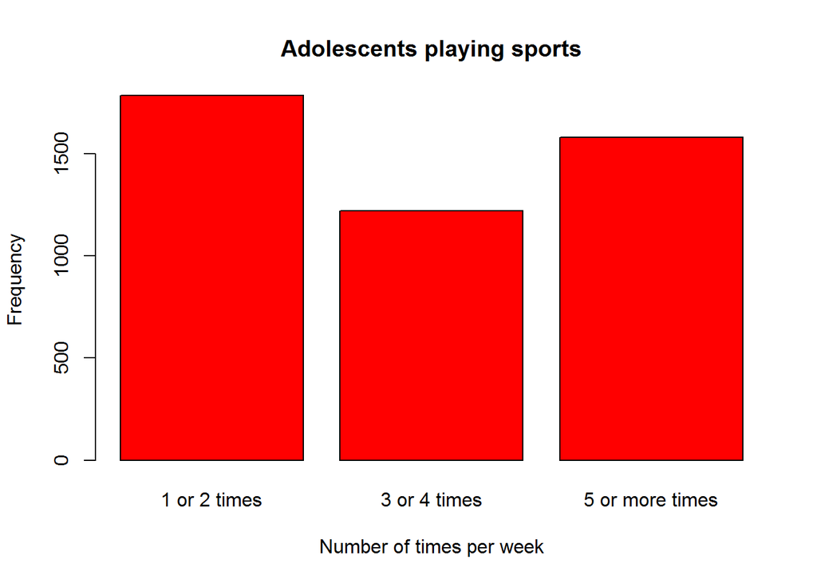

```
(AHS$Sports)
                Frequency  Percent Valid Percent
1 or 2 times         1786  38.8599         38.91
3 or 4 times         1222  26.5883         26.62
5 or more times      1582  34.4212         34.47
NA's                    6   0.1305
Total                4596 100.0000        100.00
```

```r
AHS$Sports <- factor(AHS$Sports,
                    labels = c("1 or 2 times", "3 or 4 times", "5 or more times"))

freq((AHS$Sports), main = "Adolescents playing sports", ylab = "Frequency", xlab = "Number of times per week", col = "red")
```

# Quantitative Variable:

```r
summary(AHS$TV)
```

```
   Min. 1st Qu.  Median    Mean 3rd Qu.    Max.    NA's
   0.00    5.00   12.00   16.24   21.00   99.00      20
```

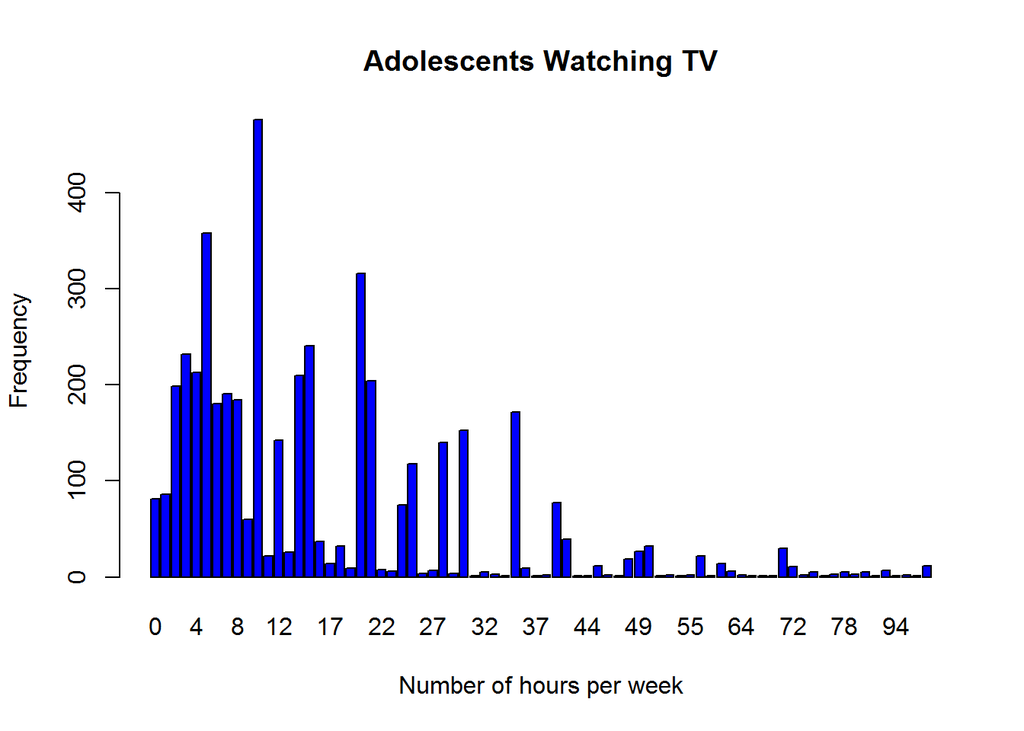

```
Hours spent watching TV
      Frequency   Percent Valid Percent
0            81   1.76240       1.77010
1            86   1.87119       1.87937
2           199   4.32985       4.34878
3           232   5.04787       5.06993
4           213   4.63446       4.65472
5           358   7.78938       7.82343
6           180   3.91645       3.93357
7           191   4.15579       4.17395
8           184   4.00348       4.02098
9            60   1.30548       1.31119
10          476  10.35683      10.40210
11           22   0.47868       0.48077
12          142   3.08964       3.10315
```

[output cut: 65 more lines]

```r
freq((AHS$TV), main = "Adolescents Watching TV", ylab = "Frequency", xlab = "Number of hours per week", col = "blue")
```

# Quantitative Variable:

```r
summary(AHS$VideoGames)
```

```
   Min. 1st Qu.  Median    Mean 3rd Qu.    Max.    NA's
  0.000   0.000   1.000   3.207   3.000  99.000       9
```

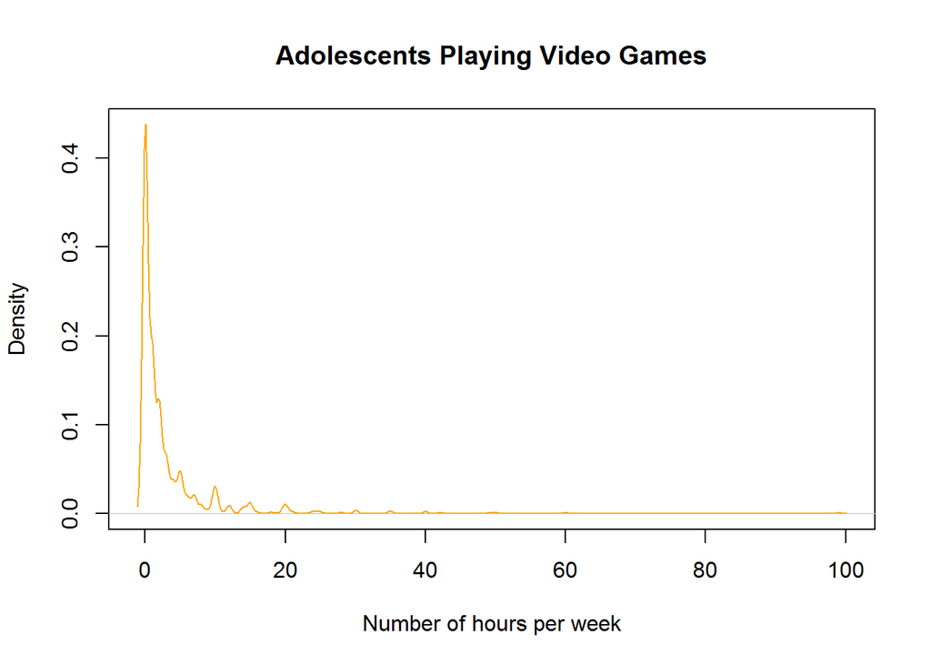

```r
plot(density(AHS$VideoGames, na.rm=TRUE),col="Orange", main="Adolescents Playing Video Games", xlab="Number of hours per week")
```

## MultiVariant Graph

```r
table(AHS$GroupieTV,AHS$Sports)
```

```
               1 or 2 times 3 or 4 times 5 or more times
  0-5 hours             461          324             384
  5-12 hours            468          334             453
  12-21 hours           424          286             379
  21-100 hours          425          276             362
```

```r
prop.table(table(AHS$GroupieTV,AHS$Sports))
```

```
               1 or 2 times 3 or 4 times 5 or more times
  0-5 hours      0.10074301   0.07080420      0.08391608
  5-12 hours     0.10227273   0.07298951      0.09899476
  12-21 hours    0.09265734   0.06250000      0.08282343
  21-100 hours   0.09287587   0.06031469      0.07910839
```

[figure not shown]

```r
barplot(prop.table(table(AHS$GroupieTV,AHS$Sports)), main="Relationship between Adolescents that play sports and watch tv", xlab= "Hours per week watching TV", ylab= "# of times playing a sport")
```

This multivariate graph shoes a comparison between the number of times adolescents play an active sport during a given week and hour many hours the spend watch TV.

# Null Hypothesis

```
              Df  Sum Sq Mean Sq F value Pr(>F)
Sports         2     478   239.1   1.047  0.351
Residuals   4573 1043978   228.3
20 observations deleted due to missingness
```

# Rejected Hypothesis

```
              Df Sum Sq Mean Sq F value   Pr(>F)
Sports         2   1063   531.7   10.14 4.04e-05 ***
Residuals   4584 240373    52.4
---
Signif. codes:  0 '***' 0.001 '**' 0.01 '*' 0.05 '.' 0.1 ' ' 1
9 observations deleted due to missingness
```

With this, it has been determined that there is at least one great significance in this data frame, because our p value is 4.04e-05.While this does not specify what set has the significant difference, it does tell us that there is one and that is what we need to look for. This is where the Post Hoc test comes into play.

## Post HOC Test

```
   1 or 2 times    3 or 4 times 5 or more times
       2.659753        3.259411        3.783681
```

```
   1 or 2 times    3 or 4 times 5 or more times
       6.111805        6.318127        8.895669
```

```
   1 or 2 times    3 or 4 times 5 or more times
              1               1               1
```

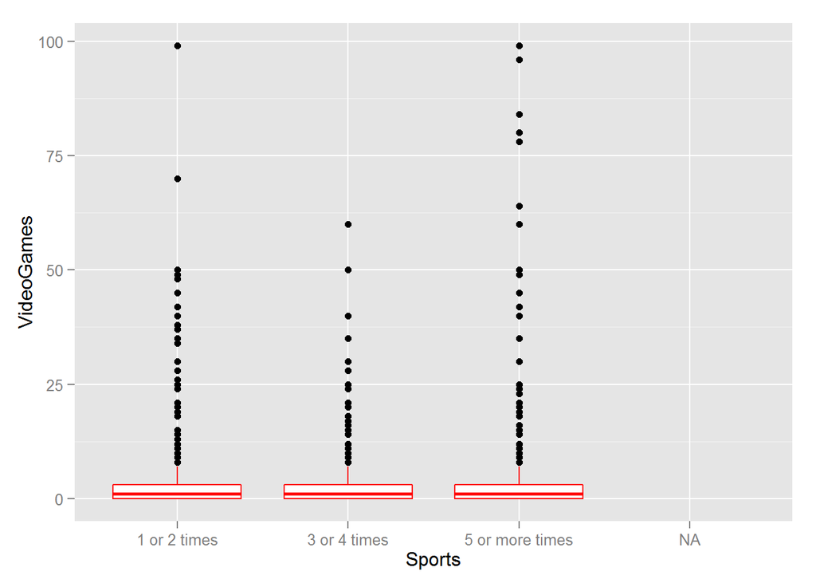

This table shows the comparison between Adolescents the play sports during a given week, and those same adolescents number of hours playing video games. The mean number of people the play an active sport `5 or more times` during a given week has a significant difference than those that play an active sport `1 or 2 times` a week.

```r
TukeyHSD(mad)
```

```
  Tukey multiple comparisons of means
    95% family-wise confidence level

Fit: aov(formula = VideoGames ~ Sports, data = AHS)

$Sports
                                  diff         lwr      upr     p adj
3 or 4 times-1 or 2 times    0.5996574 -0.03075648 1.230071 0.0663153
5 or more times-1 or 2 times 1.1239279  0.53752846 1.710327 0.0000214
5 or more times-3 or 4 times 0.5242704 -0.12238713 1.170928 0.1385522
```

## Chi-Sq Test

```r
T1 <-xtabs(~Sports+GroupieTV, data=AHS)
chisq.test(T1)
```

```
    Pearson's Chi-squared test

data:  T1
X-squared = 3.9286, df = 6, p-value = 0.6863
```

```r
T2 <-xtabs(~Sports+GroupieVG, data=AHS)
chisq.test(T2)
```

```
    Pearson's Chi-squared test

data:  T2
X-squared = 18.4092, df = 4, p-value = 0.001026
```

```r
T3 <-xtabs(~GroupieTV+GroupieVG, data=AHS)
chisq.test(T3)
```

```
    Pearson's Chi-squared test

data:  T3
X-squared = 419.0083, df = 6, p-value < 2.2e-16
```

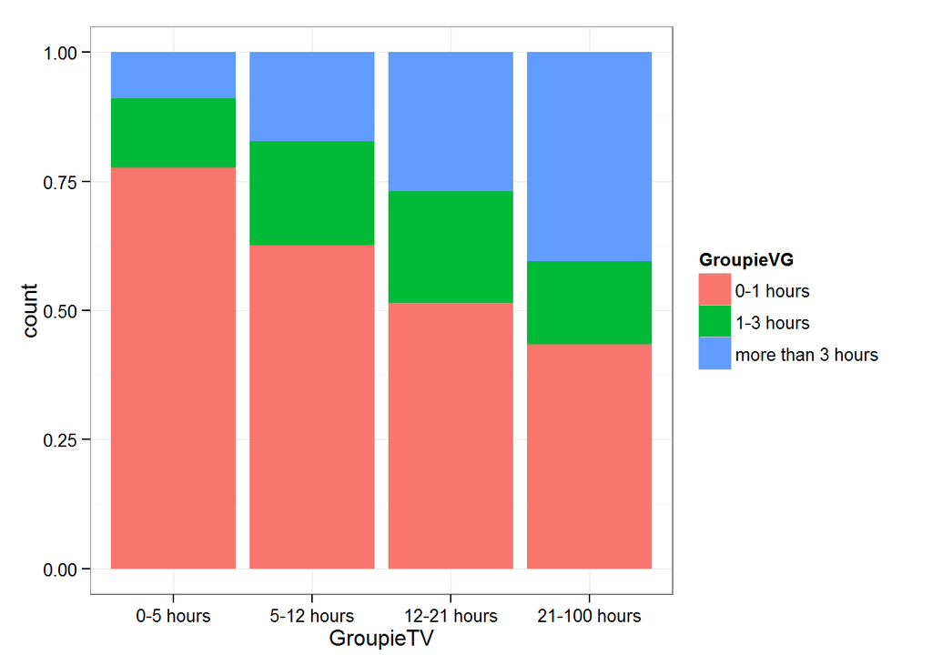

```r
ggplot(data = na.omit(AHS), aes(x = GroupieTV, fill = GroupieVG)) +
  geom_bar(position = "fill") +
  theme_bw()
```

# Post HOC Test

```r
chisq.test(T3[, c(1, 2)]) # significant
```

```
    Pearson's Chi-squared test

data:  T3[, c(1, 2)]
X-squared = 65.8717, df = 3, p-value = 3.265e-14
```

```r
chisq.test(T3[, c(1, 3)]) # significant
```

```
    Pearson's Chi-squared test

data:  T3[, c(1, 3)]
X-squared = 376.2456, df = 3, p-value < 2.2e-16
```

```r
chisq.test(T3[, c(2, 3)]) # significant
```

```
    Pearson's Chi-squared test

data:  T3[, c(2, 3)]
X-squared = 105.2927, df = 3, p-value < 2.2e-16
```

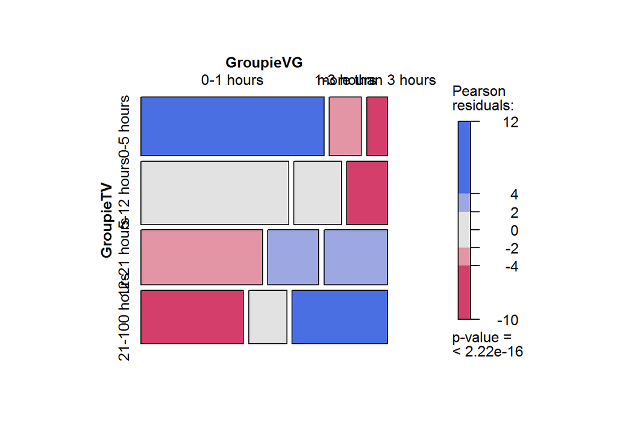

```r
library(vcd)
mosaic(T3, shade = TRUE)
```

This final graph shows that there is an association between the `GroupieTV` variable and `GroupieVG` variable. This tells us there there is an association with the amount of time adolescent spend watching TV and the amount of time the spend playing video games. When the amount of time the spend watching TV increase, the amount of time they spend playing video games also increase, showing that these to variable to be dependent.